# Introduction

- In order to help physicians identify and manage children with clinically significant hypertension, the American Academy of Pediatricians (AAP) released the [“Fourth Report on the Diagnosis, Evaluation, and Treatment of High Blood Pressure in Children and Adolescents”“](http://pediatrics.aappublications.org/content/114/Supplement_2/555.long) in 2004
  - In particular, the Fourth Report provided percentile based guidelines for systolic and diastolic blood pressure relative to height and age.
- In 2017, the AAP released updated guidelines titled [“Clinical Practice Guideline for Screening and Management of High Blood Pressure in Children and Adolescents”](http://pediatrics.aappublications.org/content/140/3/e20171904).
  - Unlike those in the Fourth Report, the data used to generate percentile values in the 2017 guidelines excluded overweight and obese individuals in order to eliminate bias from the association between body habitus and hypertension.
- This calculator provides systolic and diastolic blood pressure percentile values based on the updated 2017 guidelines.

# Modeling percentile values

# Constructing the blood pressure app

- The details of the quantile spline regression with coefficient values and testing data can be found at https://sites.google.com/a/channing.harvard.edu/bernardrosner/pediatric-blood-press/childhood-blood-pressure.

#### Generating age/height-based percentile tables

- The `percentileCalculator()` function generates the predicted 1st-99th blood pressure percentiles for a given age, sex, and height by applying the model coefficient values to the supplied data.

  ```r
  library(dplyr)
  x <- 128.2 #height
  y <- 6 #age
  w <- (y-10)*(x-150) #Interaction term between height and age

  #Call appropriate spline knots for M vs. F
  source("splineKnots_M.R")
  data.frame(t1m,t2m,t3m,t4m,t5m,ta1m,ta2m,ta3m,ta4m,ta5m,tb1m,tb2m,tb3m,tb4m,tb5m)
  ```

  ```
  ##     t1m t2m   t3m   t4m   t5m ta1m  ta2m  ta3m  ta4m ta5m tb1m tb2m   tb3m
  ## 1 107.8 140 154.5 166.4 179.1 5.06 10.79 13.22 14.51 17.3  -15  8.9 50.375
  ##      tb4m   tb5m
  ## 1 112.684 250.04
  ```

  ```r
  #Manually adjust knot points based on height, age, and interaction term (copied from published SAS code)
  if (x-t1m < 0) {x2a=0} else {x2a=x-t1m}
  if (x-t4m < 0) {x2b=0} else {x2b=x-t4m}
  if (x-t5m < 0) {x2c=0} else {x2c=x-t5m}
  x2=x2a^3-x2b^3*(t5m-t1m)/(t5m-t4m)+x2c^3*(t4m-t1m)/(t5m-t4m)
  if (x-t2m < 0) {x3a=0} else {x3a=x-t2m}
  x3=x3a^3-x2b^3*(t5m-t2m)/(t5m-t4m)+x2c^3*(t4m-t2m)/(t5m-t4m)
  if (x-t3m < 0) {x4a=0} else {x4a=x-t3m}
  x4=x4a^3-x2b^3*(t5m-t3m)/(t5m-t4m)+x2c^3*(t4m-t3m)/(t5m-t4m)
  x2s=x2/100
  x3s=x3/100
  x4s=x4/100

  if (y-ta1m < 0 ) { y2a=0}  else {y2a=y-ta1m}
  if (y-ta4m < 0 ) { y2b=0}  else {y2b=y-ta4m}
  if (y-ta5m < 0 ) { y2c=0}  else {y2c=y-ta5m}
  y2=y2a^3-y2b^3*(ta5m-ta1m)/(ta5m-ta4m)+y2c^3*(ta4m-ta1m)/(ta5m-ta4m)
  if (y-ta2m < 0 ) { y3a=0}  else {y3a=y-ta2m}
  y3=y3a^3-y2b^3*(ta5m-ta2m)/(ta5m-ta4m)+y2c^3*(ta4m-ta2m)/(ta5m-ta4m)
  if (y-ta3m < 0 ) { y4a=0}  else {y4a=y-ta3m}
  y4=y4a^3-y2b^3*(ta5m-ta3m)/(ta5m-ta4m)+y2c^3*(ta4m-ta3m)/(ta5m-ta4m)
  y2s=y2/100
  y3s=y3/100
  y4s=y4/100

  if (w-tb1m < 0 ) { w2a=0}  else {w2a=w-tb1m}
  if (w-tb4m < 0 ) { w2b=0}  else {w2b=w-tb4m}
  if (w-tb5m < 0 ) { w2c=0}  else {w2c=w-tb5m}
  w2=w2a^3-w2b^3*(tb5m-tb1m)/(tb5m-tb4m)+w2c^3*(tb4m-tb1m)/(tb5m-tb4m)
  if (w-tb2m < 0 ) { w3a=0}  else {w3a=w-tb2m}
  w3=w3a^3-w2b^3*(tb5m-tb2m)/(tb5m-tb4m)+w2c^3*(tb4m-tb2m)/(tb5m-tb4m)
  if (w-tb3m < 0 ) { w4a=0}  else {w4a=w-tb3m}
  w4=w4a^3-w2b^3*(tb5m-tb3m)/(tb5m-tb4m)+w2c^3*(tb4m-tb3m)/(tb5m-tb4m)
  w2s=w2/100^2
  w3s=w3/100^2
  w4s=w4/100^2

  spline.position <- c("1"=1, "x"=x, "x2s"=x2s, "x3s"=x3s, "x4s"=x4s,
                     "y"=y, "y2s"=y2s, "y3s"=y3s, "y4s"=y4s,
                     "w"=w, "w2s"=w2s, "w3s"=w3s, "w4s"=w4s)
  spline.position
  ```

  ```
  ##            1            x          x2s          x3s          x4s
  ##   1.00000000 128.20000000  84.89664000   0.00000000   0.00000000
  ##            y          y2s          y3s          y4s            w
  ##   6.00000000   0.00830584   0.00000000   0.00000000  87.20000000
  ##          w2s          w3s          w4s
  ## 106.74626480  48.00486870   4.99376690
  ```

  ```r
  #Call appropriate regression coefficients for M vs. F and SBP vs. DBP
  df <- read.csv("SBP_M_coef.csv", row.names = 1)
  df <- df %>%
    select(b0sys,
           b1sys,b2sys,b3sys,b4sys,
           ba1sys,ba2sys,ba3sys,ba4sys,
           bb1sys,bb2sys,bb3sys,bb4sys)
  head(df)
  ```

  ```
  ##         b0sys  b1sys   b2sys  b3sys   b4sys  ba1sys ba2sys   ba3sys
  ## 0.01 -15.1614 0.7016 -0.0159 0.0803 -0.1501  0.1585 0.7927 -16.2445
  ## 0.02   7.1181 0.5512 -0.0095 0.0540 -0.1228  0.1808 0.1658  -8.1838
  ## 0.03  16.6833 0.5000 -0.0072 0.0370 -0.0808 -0.0164 0.2766  -6.0204
  ## 0.04   4.2312 0.5830 -0.0104 0.0473 -0.0885  0.3344 0.0389  -4.8857
  ## 0.05   7.5365 0.5865 -0.0109 0.0523 -0.0938 -0.0042 0.4065  -5.8405
  ## 0.06   9.1488 0.6019 -0.0121 0.0661 -0.1243 -0.3319 0.8441  -9.4288
  ##       ba4sys  bb1sys bb2sys  bb3sys  bb4sys
  ## 0.01 64.9588  0.0109 0.1002 -0.1603  0.0565
  ## 0.02 41.4072  0.0057 0.0042  0.0299 -0.0661
  ## 0.03 29.5897 -0.0092 0.0673 -0.0993  0.0246
  ## 0.04 26.2991  0.0009 0.0958 -0.1550  0.0586
  ## 0.05 25.1459  0.0010 0.0934 -0.1598  0.0738
  ## 0.06 35.3411 -0.0028 0.1050 -0.1870  0.0975
  ```

  ```r
  #Manually calculate quantile values from combination of knot points and coefficients
  df <- data.frame(t(apply(df, 1, function(x) x*spline.position)))
  df <- data.frame(percentile = 1:99/100, fxsys = apply(df, 1, sum))
  #The above 2 lines corresponds to the published SAS code:
      # array b0sys{*}  inter1-inter99;
      # array b1sys{*}  b1sys1-b1sys99;
      # array b2sys{*}  b2sys1-b2sys99;
      # array b3sys{*}  b3sys1-b3sys99;
      # array b4sys{*}  b4sys1-b4sys99;
      # array ba1sys{*} ba1sys1-ba1sys99;
      # array ba2sys{*} ba2sys1-ba2sys99;
      # array ba3sys{*} ba3sys1-ba3sys99;
      # array ba4sys{*} ba4sys1-ba4sys99;
      # array bb1sys{*} bb1sys1-bb1sys99;
      # array bb2sys{*} bb2sys1-bb2sys99;
      # array bb3sys{*} bb3sys1-bb3sys99;
      # array bb4sys{*} bb4sys1-bb4sys99;
      # array fxsys{*}  fxsys1-fxsys99;
      # array difsys{*} difsys1-difsys99;
      #
      # do i=1 to 99;
      #   fxsys{i}=b0sys{i}+b1sys{i}*x+b2sys{i}*x2s+b3sys{i}*x3s+b4sys{i}*x4s
      #           +ba1sys{i}*y+ba2sys{i}*y2s+ba3sys{i}*y3s+ba4sys{i}*y4s
      #           +bb1sys{i}*w+bb2sys{i}*w2s+bb3sys{i}*w3s+bb4sys{i}*w4s;
      #   difsys{i} =abs(sysbp-fxsys{i});
      # end;
  head(df)
  ```

  ```
  ##      percentile    fxsys
  ## 0.01       0.01 78.62487
  ## 0.02       0.02 80.11223
  ## 0.03       0.03 81.81369
  ## 0.04       0.04 83.25225
  ## 0.05       0.05 84.53327
  ## 0.06       0.06 85.77492
  ```

  ```r
  #Same result is acheived from the function
  source("percentileCalculator.R")
  head(percentileCalculator(age = 6, height = 128.2, sex = "M", SBP.DBP = "SBP"))
  ```

  ```
  ##      percentile    fxsys
  ## 0.01       0.01 78.62487
  ## 0.02       0.02 80.11223
  ## 0.03       0.03 81.81369
  ## 0.04       0.04 83.25225
  ## 0.05       0.05 84.53327
  ## 0.06       0.06 85.77492
  ```

- This indicates that, for a 6 year old male with a height of 128.2cm, the 1st percentile for SBP would be 78.6, the 2nd percentile would be 80.1, and so on.

#### Calculating patient specific values and cutoffs

- The `BPappCalculation()` function takes the output from `percentileCalculator()` and applies it to an individual’s blood pressure to generate the patient’s BP percentile, guideline cutoff values, and a graphical representation of the data

  ```r
  library(ggplot2)
  BP <- 87.166
  table <- percentileCalculator(6, 128.2, "M", "SBP")
  #Calculates the patient's percentile based on finding the value in the percentil table with the least difference to the patient's blood pressure
  pcnt <- which.min(abs(BP-table$fxsys))
  #The median BP for the patient's demographic is the 50th percentile
  median <- table$fxsys[50]
  #Guidelines specify the 90th percentile as elevated
  elevated <- table$fxsys[90]
  #Guidelines specify the 95th percentile as stage 1 hypertension
  stage1 <- table$fxsys[95]
  #Guidelines specify 12mmHg above the 95th percentile as stage 2 hypertension
  stage2 <- stage1+12
  #The following generates a plot of the patient's blood pressure relative to the values on the percentile table, annotated by guideline criteria
  plot <- ggplot(table, aes(x = fxsys, y = percentile*100)) +
    geom_area(data=table[which(table$fxsys<=elevated),], fill = "green", alpha = 0.25)+
    geom_area(data=table[which(table$fxsys>=elevated & table$fxsys<=stage1),], fill = "yellow", alpha = 0.25)+
    geom_area(data=table[which(table$fxsys>=stage1),], fill = "red", alpha = 0.25)+
    geom_line(size=1) +
    geom_point(aes(x = BP, y = pcnt), shape = 21, color = "black", fill= "red", size = 3, stroke = 2) +
    theme_classic() +
    labs(x="mmHg", y="Percentile") +
    theme(plot.title = element_text(hjust = 0.5,
                                    size = 16,
                                    face = "bold"))
  #All the above values are contained within a list
  output <- list(
    "table" = table,
    "pcnt" = pcnt,
    "median" = median,
    "elevated" = elevated,
    "stage1" = stage1,
    "stage2" = stage2,
    "plot" = plot
  )
  data.frame(output$pcnt, output$median, output$elevated, output$stage1, output$stage2)
  ```

  ```
  ##   output.pcnt output.median output.elevated output.stage1 output.stage2
  ## 1           9      98.30789        111.0179       114.463       126.463
  ```

  ```r
  #Same result is acheived from the function
  source("BPappCalculations.R")
  output <- BPappCalculations(age = 6, height = 128.2, sex = "M", SBP.DBP = "SBP", BP = 87.166)
  data.frame(output$pcnt, output$median, output$elevated, output$stage1, output$stage2)
  ```

  ```
  ##   output.pcnt output.median output.elevated output.stage1 output.stage2
  ## 1           9      98.30789        111.0179       114.463       126.463
  ```

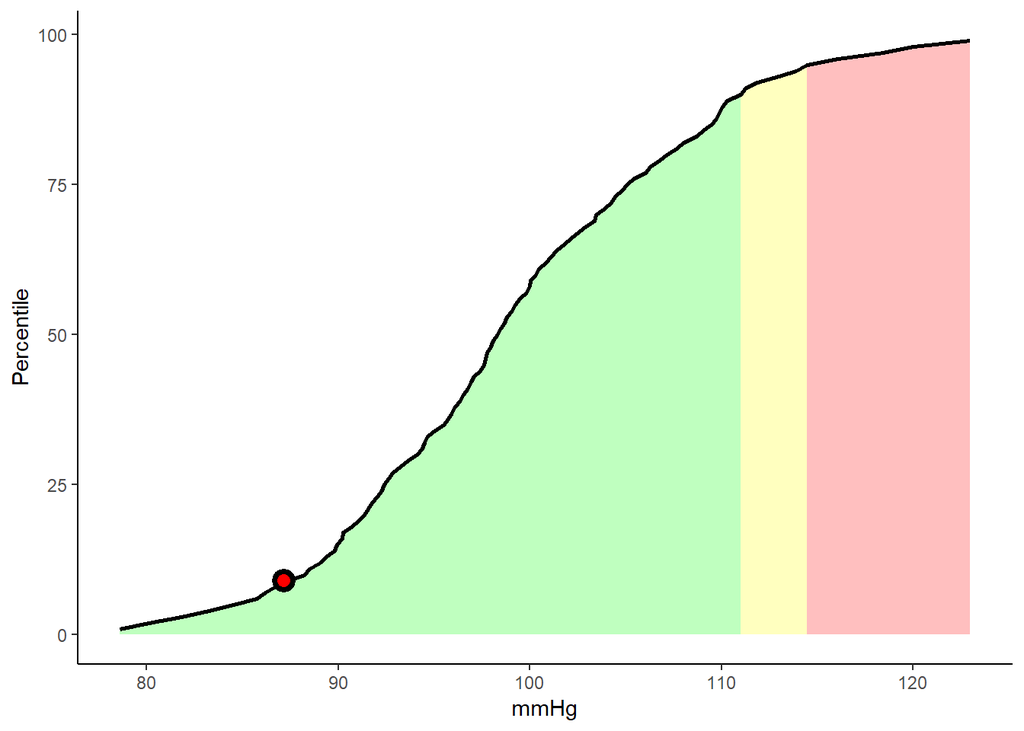

  ```r
  output$plot
  ```

# Validating the app

- The original source information includes a test data set `sample_data.txt` as well as `sample_output.txt` that includes both this data and the results of passing it through the published `childhoodbppct.sas` SAS code.

  ```r
  df <- read.table("sample_output.txt", header = T, stringsAsFactors = F)
  head(df)
  ```

  ```
  ##   Obs  id sex age height outlier   sysbp syspct  diask5 diaspct
  ## 1   1   1   1  14  116.5       1       .      . 83.0000       .
  ## 2   2   2   2  16  112.3       1       .      . 74.0000       .
  ## 3   3   3   2  17  113.9       1 122.000      .       .       .
  ## 4   4   4   1  12  116.1       1 121.000      .       .       .
  ## 5   5   5   1  18  116.1       1 121.000      .       .       .
  ## 6   6 104   1  14  165.4       0  97.714     10       .       .
  ```

  - `sex` is the coded sex with male = 1 and female = 2
  - `sysbp` and `diask5` represent the patient’s systolic and diastolic blood pressure, respectively
  - For these columns, `.` represents missing data
  - `syspct` and `diaspct` represent the calculated systolic and diastolic blood pressure percentiles, respectively, by `childhoodbppct.sas`
  - For these columns, `.` represents data that was not calculated either due to missing input data or due to the patient’s height representing an age-adjusted outlier
- We will perform some data cleanup to refactor, rename, and and exclude incomplete data for this test

  ```r
  library(dplyr); library(ggplot2)
  df <- df %>% mutate(sex = recode(sex, "1" = "M", "2" = "F"),
           age= as.numeric(age),
           height = as.numeric(height),
           SBP = as.numeric(sysbp),
           DBP = as.numeric(diask5),
           pub.SBP.pct = syspct,
           pub.DBP.pct = diaspct
           ) %>%
    na.omit %>% select(Obs, sex, age, height, SBP, DBP, pub.SBP.pct, pub.DBP.pct)
  head(df)
  ```

  ```
  ##    Obs sex     age height     SBP     DBP pub.SBP.pct pub.DBP.pct
  ## 7    7   M 14.7917  152.9 116.047 53.2416          84          30
  ## 8    8   M  6.0000  128.2  87.166 57.9352           9          48
  ## 9    9   M 15.0000  170.7 119.714 67.9091          72          59
  ## 11  11   F  9.0000  123.5  88.714 44.7809          28          14
  ## 12  12   M 11.0000  145.9 111.714 51.9091          85          17
  ## 13  13   M  7.0000  121.3  91.714 51.9091          33          29
  ```

- Now we will calculate blood pressure percentiles using our function

  ```r
  source("BPappCalculations.R"); source("percentileCalculator.R")
  df <- df %>%
    mutate(calc.SBP.pct =
             unlist(apply(., 1, function(x)
               BPappCalculations(
                 age = as.numeric(x['age']),
                 height = as.numeric(x['height']),
                 sex = x['sex'],
                 BP = as.numeric(x['SBP']),
                 SBP.DBP = "SBP"
               )$pcnt)),
           calc.DBP.pct =
             unlist(apply(., 1, function(x)
               BPappCalculations(
                 age = as.numeric(x['age']),
                 height = as.numeric(x['height']),
                 sex = x['sex'],
                 BP = as.numeric(x['DBP']),
                 SBP.DBP = "DBP"
               )$pcnt))) %>%
    select(Obs, pub.SBP.pct, calc.SBP.pct, pub.DBP.pct, calc.DBP.pct)
  head(df)
  ```

  ```
  ##   Obs pub.SBP.pct calc.SBP.pct pub.DBP.pct calc.DBP.pct
  ## 1   7          84           84          30           30
  ## 2   8           9            9          48           48
  ## 3   9          72           72          59           59
  ## 4  11          28           28          14           14
  ## 5  12          85           85          17           17
  ## 6  13          33           33          29           29
  ```

- When you compare the `pub.` and `calc.` values of a patients systolic or diastolic percentiles, you will see that the values are identical, indicating that our function generates the same results as the published SAS code.